# cma-week3

Martine Besse

2023-05-05

```r
library("readr")
library("dplyr")
```

```r
library("ggplot2")
```

# Wildboar data

## Preparation: import data

```r
wildschwein <- read_csv("data/wildschwein_BE_2056.csv")
wildschwein
```

```
## # A tibble: 51,246 × 6
##    TierID TierName CollarID DatetimeUTC                E        N
##    <chr>  <chr>       <dbl> <dttm>                 <dbl>    <dbl>
##  1 002A   Sabi        12275 2014-08-22 21:00:12 2570409. 1204752.
##  2 002A   Sabi        12275 2014-08-22 21:15:16 2570402. 1204863.
##  3 002A   Sabi        12275 2014-08-22 21:30:43 2570394. 1204826.
##  4 002A   Sabi        12275 2014-08-22 21:46:07 2570379. 1204817.
##  5 002A   Sabi        12275 2014-08-22 22:00:22 2570390. 1204818.
##  6 002A   Sabi        12275 2014-08-22 22:15:10 2570390. 1204825.
##  7 002A   Sabi        12275 2014-08-22 22:30:13 2570387. 1204831.
##  8 002A   Sabi        12275 2014-08-22 22:45:11 2570381. 1204840.
##  9 002A   Sabi        12275 2014-08-22 23:00:27 2570316. 1204935.
## 10 002A   Sabi        12275 2014-08-22 23:15:41 2570393. 1204815.
## # ℹ 51,236 more rows
```

Extract Sabi:

! specific timezone otherwise, just text we might have difference because of it, and issue with summer and winter time.

```r
#number of animals:
wildschwein$TierName %>% unique()
```

```
## [1] "Sabi" "Rosa" "Ruth"
```

```r
#extract sabi:
sabi <- wildschwein %>% filter(TierName == "Sabi") %>%
  filter(DatetimeUTC >= as.POSIXct("2015-07-01", tz = "UTC"), DatetimeUTC < as.POSIXct("2015-07-03", tz = "UTC"))
```

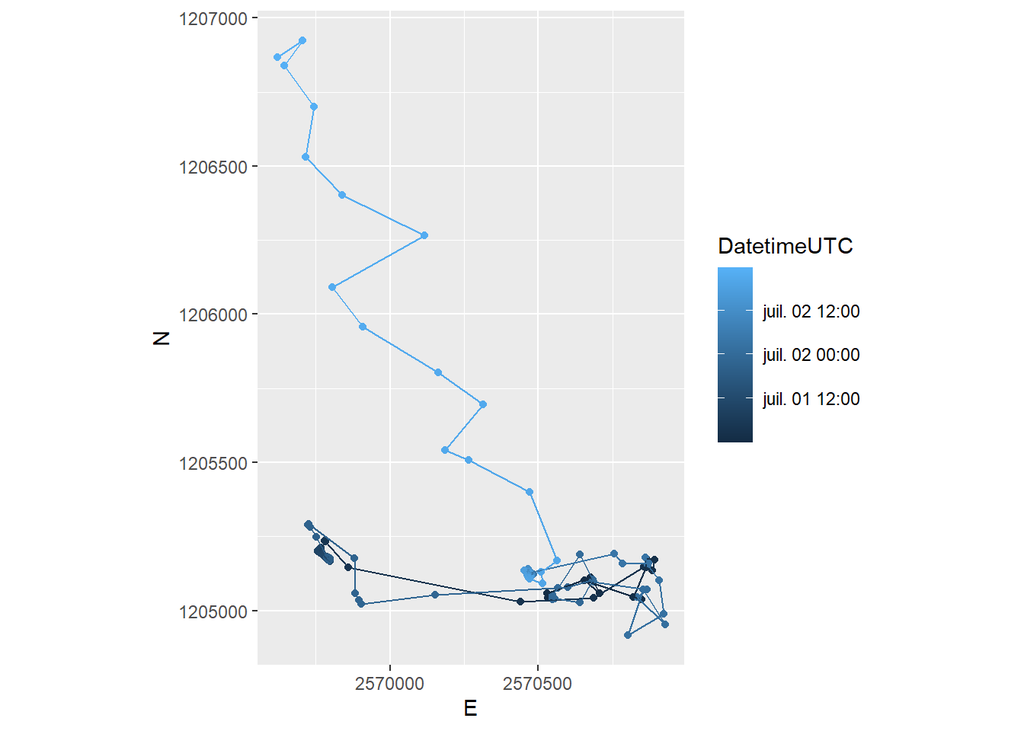

```r
#plot sabi trajectories
ggplot(sabi, aes(E,N, color = DatetimeUTC)) +
  geom_point() +
  geom_path() +
  coord_equal() #so equally space North and East
```

## Step a) specify a temporal window

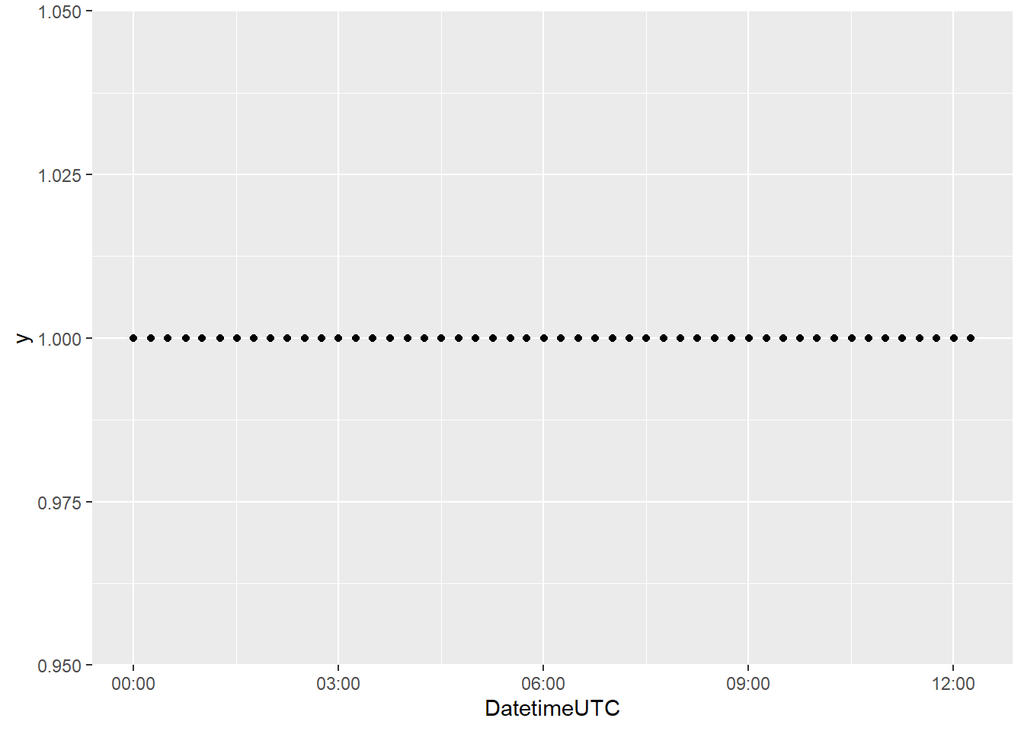

```r
#visualise:
sabi %>% head(50) %>%
  ggplot(aes(DatetimeUTC, 1)) +
  geom_point()
```

Temporal window of 60 minutes: 4 fixes  
pos[n-2] to pos[n]  
pos[n-1] to pos[n]  
pos[n] to pos[n+1]  
pos[n] to pos[n+2]

```r
sabi <- sabi %>%
  mutate(
    n_plus1 = sqrt((lead(E)-E)^2 + (lead(N)-N)^2), #from n to n+1
    n_plus2 = sqrt((lead(E, 2)-E)^2 + (lead(N, 2)-N)^2), #from n to n+2
    n_minus1 = sqrt((lag(E, 1)-E)^2 + (lag(N, 1)-N)^2), #from n to n-1
    n_minus2 = sqrt((lag(E, 2)-E)^2 + (lag(N, 2)-N)^2) #from n to n-2
  )
#reminder:
#lead() = next value of E
#lag() = opposite of lead()
#numbers <- 1:10
#lead(numbers, n = 2) #discard first 2
#lag(numbers, n = 5) #discard last 5

sabi
```

```
## # A tibble: 192 × 10
##    TierID TierName CollarID DatetimeUTC                E       N n_plus1 n_plus2
##    <chr>  <chr>       <dbl> <dttm>                 <dbl>   <dbl>   <dbl>   <dbl>
##  1 002A   Sabi        12275 2015-07-01 00:00:10 2570532.  1.21e6    15.4   159.
##  2 002A   Sabi        12275 2015-07-01 00:15:14 2570530.  1.21e6   155.    177.
##  3 002A   Sabi        12275 2015-07-01 00:30:11 2570676.  1.21e6    63.1    22.0
##  4 002A   Sabi        12275 2015-07-01 00:45:43 2570707.  1.21e6    68.3   144.
##  5 002A   Sabi        12275 2015-07-01 01:00:20 2570656.  1.21e6   204.    173.
##  6 002A   Sabi        12275 2015-07-01 01:15:59 2570850.  1.21e6    31.7   112.
##  7 002A   Sabi        12275 2015-07-01 01:31:02 2570819.  1.21e6   112.    137.
##  8 002A   Sabi        12275 2015-07-01 01:45:37 2570863.  1.21e6    27.1    35.5
##  9 002A   Sabi        12275 2015-07-01 02:00:17 2570863.  1.21e6    29.2    45.7
## 10 002A   Sabi        12275 2015-07-01 02:15:13 2570891.  1.21e6    35.5    37.7
## # ℹ 182 more rows
## # ℹ 2 more variables: n_minus1 <dbl>, n_minus2 <dbl>
```

## Step b) Measure the distance from every point to every otehr point within this temporal window

Important to specify na.rm in the mean function, otherwise na values interfer.

```r
sabi <- sabi |>
  rowwise() |> #group by row with rowwise(), otherwise the mutates give one result for everything
  mutate(
    stepMean = mean(c(n_minus1, n_minus2, n_plus1, n_plus2), na.rm = TRUE)
  ) |>
  ungroup() #to ungroup rowwise()
```

## Step c) Remove “static points”

Determines a threshold where we consider our animal not to be moving.

Check if we could use the mean as the threshold:

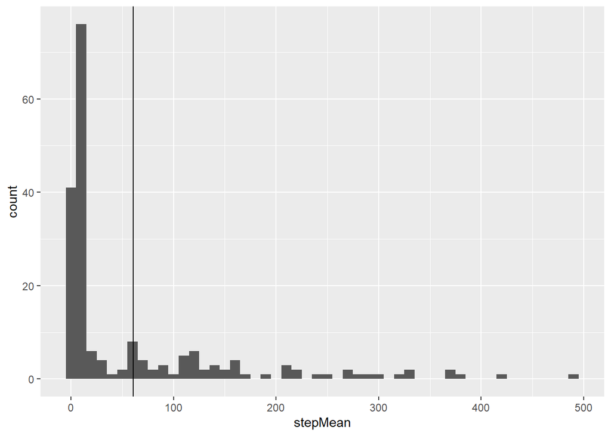

```r
ggplot(sabi, aes(stepMean)) +
  geom_histogram(binwidth = 10) +
  geom_vline(xintercept = mean(sabi$stepMean, na.rm = TRUE))
```

Use the mean as a threshold:

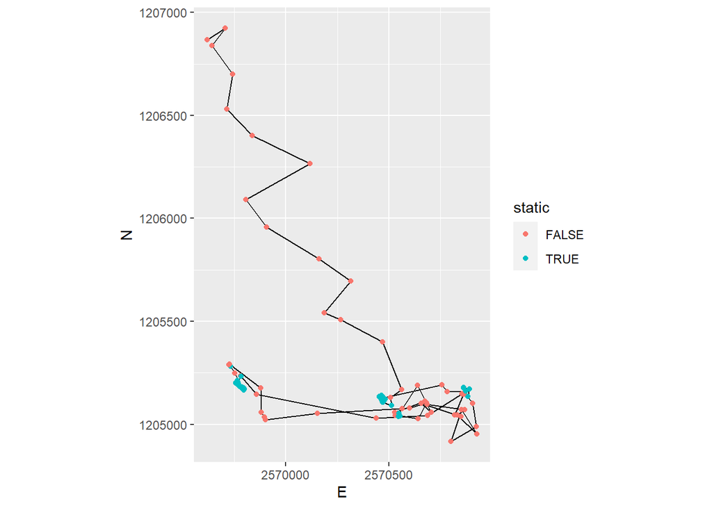

```r
sabi |>
  mutate(static = stepMean < mean(stepMean, na.rm = TRUE)) |>
  ggplot(aes(E, N)) +
  geom_path() +
  geom_point(aes(color = static)) + # color of points show if the points are statics or not
  coord_fixed()
```

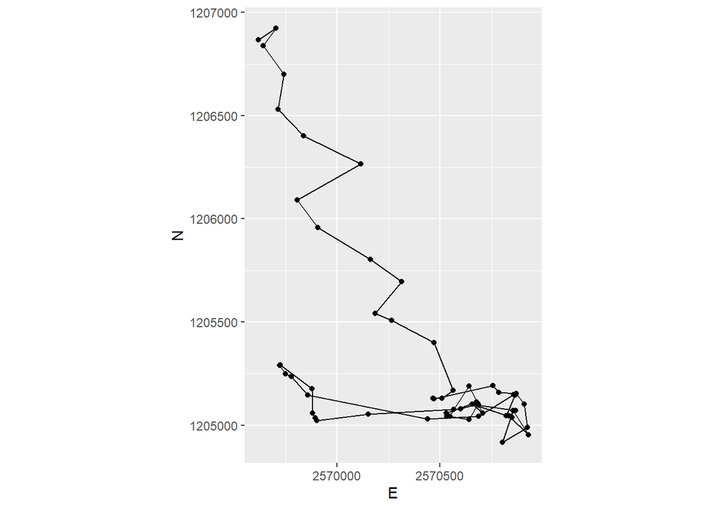

```r
# filter sabi data
sabi <- sabi |>
  mutate(static = stepMean < mean(stepMean, na.rm = TRUE))

sabi_filter <- sabi |>
    filter(!static)

#plot
sabi_filter |>
    ggplot(aes(E, N)) +
    geom_path() +
    geom_point() +
    coord_fixed() +
    theme(legend.position = "bottom")
```

# Posmo data

## Preparation

```r
library("readr")
library("sf")
posmo <- read_delim("data/posmo_2023-01-01T00_00_00+01_00-2023-05-11T23_59_59+02_00.csv")
# Keep only the necessary columns
posmo <- select(posmo, datetime, lon_x, lat_y)
```

Transform to MN95:

```r
posmo <- st_as_sf(posmo, coords = c("lon_x","lat_y"), crs = 4326) |>
  st_transform(2056)

head(posmo)
```

```
## Simple feature collection with 6 features and 1 field
## Geometry type: POINT
## Dimension:     XY
## Bounding box:  xmin: 2550265 ymin: 1194674 xmax: 2556120 ymax: 1202625
## Projected CRS: CH1903+ / LV95
## # A tibble: 6 × 2
##   datetime                     geometry
##   <dttm>                    <POINT [m]>
## 1 2023-03-30 15:40:56 (2556120 1202625)
## 2 2023-03-30 15:41:05 (2555910 1202492)
## 3 2023-03-30 15:41:15 (2555629 1202324)
## 4 2023-03-30 15:41:32 (2555166 1202092)
## 5 2023-03-30 15:41:41 (2554897 1201957)
## 6 2023-03-30 15:45:33 (2550265 1194674)
```

```r
posmo_coordinates <- st_coordinates(posmo)

posmo <- cbind(posmo, posmo_coordinates)
posmo
```

```
## Simple feature collection with 26038 features and 3 fields
## Geometry type: POINT
## Dimension:     XY
## Bounding box:  xmin: 2514666 ymin: 1106915 xmax: 2694102 ymax: 1256849
## Projected CRS: CH1903+ / LV95
## First 10 features:
##               datetime       X       Y                geometry
## 1  2023-03-30 15:40:56 2556120 1202625 POINT (2556120 1202625)
## 2  2023-03-30 15:41:05 2555910 1202492 POINT (2555910 1202492)
## 3  2023-03-30 15:41:15 2555629 1202324 POINT (2555629 1202324)
## 4  2023-03-30 15:41:32 2555166 1202092 POINT (2555166 1202092)
## 5  2023-03-30 15:41:41 2554897 1201957 POINT (2554897 1201957)
## 6  2023-03-30 15:45:33 2550265 1194674 POINT (2550265 1194674)
## 7  2023-03-30 15:45:42 2549951 1194430 POINT (2549951 1194430)
## 8  2023-03-30 15:45:42 2549891 1194429 POINT (2549891 1194429)
## 9  2023-03-30 15:45:42 2549891 1194429 POINT (2549891 1194429)
## 10 2023-03-30 15:45:42 2549891 1194429 POINT (2549891 1194429)
```

Select one single date:

```r
posmo_filter <- posmo |>
    filter(as.Date(datetime) == "2023-05-4")
posmo_filter
```

```
## Simple feature collection with 307 features and 3 fields
## Geometry type: POINT
## Dimension:     XY
## Bounding box:  xmin: 2681929 ymin: 1247434 xmax: 2684284 ymax: 1251835
## Projected CRS: CH1903+ / LV95
## First 10 features:
##               datetime       X       Y                geometry
## 1  2023-05-04 05:35:56 2682030 1251792 POINT (2682030 1251792)
## 2  2023-05-04 05:35:56 2682173 1251661 POINT (2682173 1251661)
## 3  2023-05-04 05:36:06 2682149 1251639 POINT (2682149 1251639)
## 4  2023-05-04 05:36:15 2682155 1251636 POINT (2682155 1251636)
## 5  2023-05-04 05:36:24 2682169 1251617 POINT (2682169 1251617)
## 6  2023-05-04 05:36:33 2682188 1251603 POINT (2682188 1251603)
## 7  2023-05-04 05:36:42 2682205 1251582 POINT (2682205 1251582)
## 8  2023-05-04 05:36:51 2682222 1251560 POINT (2682222 1251560)
## 9  2023-05-04 05:37:00 2682238 1251544 POINT (2682238 1251544)
## 10 2023-05-04 05:37:09 2682255 1251527 POINT (2682255 1251527)
```

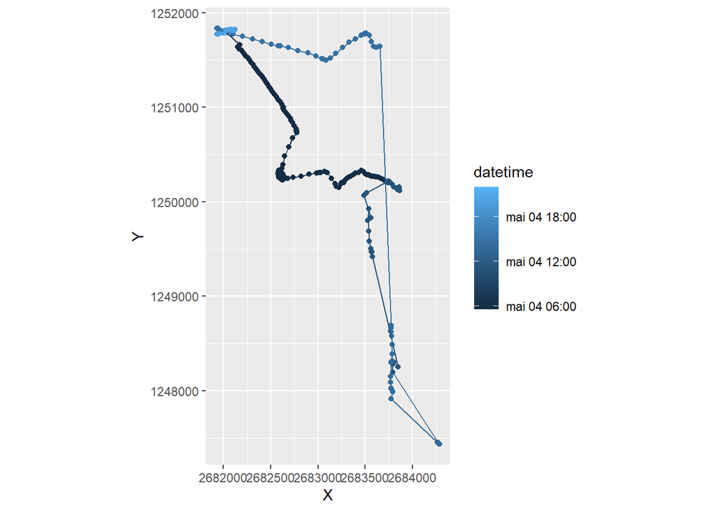

```r
#plot trajectories
ggplot(posmo_filter, aes(X,Y, color = datetime)) +
  geom_point() +
  geom_path() +
  coord_equal() #so equally space North and East
```

Add useful attributes:

```r
#timelag
posmo_filter <- mutate(posmo_filter, timelag = as.numeric(difftime(lead(datetime), datetime)))

#steplength
posmo_filter <- posmo_filter %>% mutate(steplength_m = sqrt((X-lead(X))^2 + (Y-lead(Y))^2))

#speed
posmo_filter <- posmo_filter %>% mutate(speed_ms = steplength_m/timelag)
```

## Task 1: Segmentation

### Step a) specify a temporal window

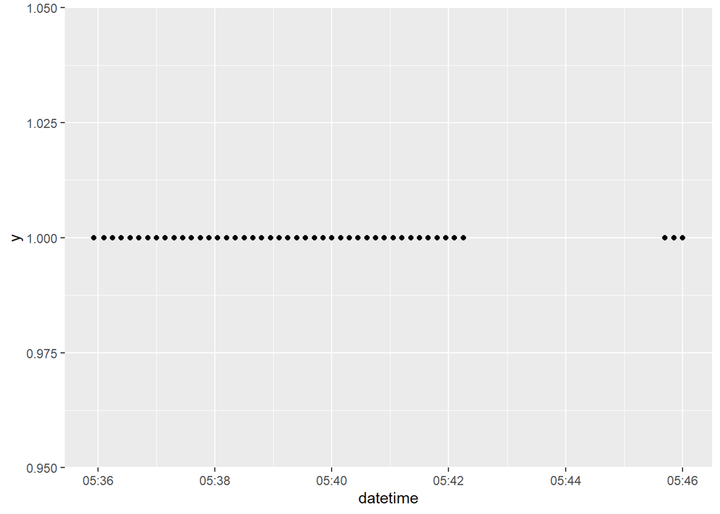

```r
#visualise:
posmo_filter %>% head(50) %>%
  ggplot(aes(datetime, 1)) +
  geom_point()
```

```r
posmo_filter <- posmo_filter %>%
  mutate(
    n_plus1 = sqrt((lead(X)-X)^2 + (lead(Y)-Y)^2), #from n to n+1
    n_plus2 = sqrt((lead(X, 2)-X)^2 + (lead(Y, 2)-Y)^2), #from n to n+2
    n_plus3 = sqrt((lead(X, 3)-X)^2 + (lead(Y, 3)-Y)^2), #from n to n+3
    n_minus1 = sqrt((lag(X, 1)-X)^2 + (lag(Y, 1)-Y)^2), #from n to n-1
    n_minus2 = sqrt((lag(X, 2)-X)^2 + (lag(Y, 2)-Y)^2), #from n to n-2
    n_minus3 = sqrt((lag(X, 3)-X)^2 + (lag(Y, 3)-Y)^2) #from n to n-3
  )

posmo_filter
```

```
## Simple feature collection with 307 features and 12 fields
## Geometry type: POINT
## Dimension:     XY
## Bounding box:  xmin: 2681929 ymin: 1247434 xmax: 2684284 ymax: 1251835
## Projected CRS: CH1903+ / LV95
## First 10 features:
##               datetime       X       Y                geometry timelag
## 1  2023-05-04 05:35:56 2682030 1251792 POINT (2682030 1251792)       0
## 2  2023-05-04 05:35:56 2682173 1251661 POINT (2682173 1251661)      10
## 3  2023-05-04 05:36:06 2682149 1251639 POINT (2682149 1251639)       9
## 4  2023-05-04 05:36:15 2682155 1251636 POINT (2682155 1251636)       9
## 5  2023-05-04 05:36:24 2682169 1251617 POINT (2682169 1251617)       9
## 6  2023-05-04 05:36:33 2682188 1251603 POINT (2682188 1251603)       9
## 7  2023-05-04 05:36:42 2682205 1251582 POINT (2682205 1251582)       9
## 8  2023-05-04 05:36:51 2682222 1251560 POINT (2682222 1251560)       9
```

[output cut: 24 more lines]

### Step b) Measure the distance from every point to every other point within this temporal window

Important to specify na.rm in the mean function, otherwise na values interfer.

```r
posmo_filter <- posmo_filter |>
  rowwise() |> #group by row with rowwise(), otherwise the mutates give one result for everything
  mutate(
    stepMean = mean(c(n_minus1, n_minus2, n_minus3, n_plus1, n_plus2, n_plus3), na.rm = TRUE)
  ) |>
  ungroup() #to ungroup rowwise()
```

## Task 2: Specify and apply threshold d

Explore stepMean using summary statistics:

```r
summary(posmo_filter$stepMean)
```

```
##    Min. 1st Qu.  Median    Mean 3rd Qu.    Max.
##    0.00   20.23   52.03   91.41   89.47 1502.60
```

### Step c) Remove “static points”

Determines a threshold where we consider we are not moving.

Check if we could use the mean as the threshold:

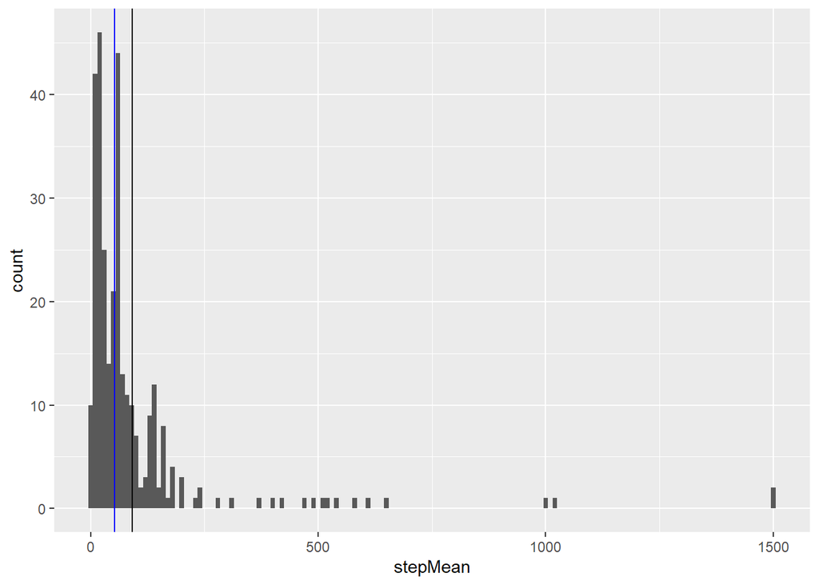

```r
ggplot(posmo_filter, aes(stepMean)) +
  geom_histogram(binwidth = 10) +
  geom_vline(xintercept = mean(posmo_filter$stepMean, na.rm = TRUE)) +
  geom_vline(xintercept = median(posmo_filter$stepMean, na.rm = TRUE), color='blue')
```

It seems the mean 91.413772 neither the median 52.0332726 are really adequate.

## Task 3: Visualize segmented trajectories

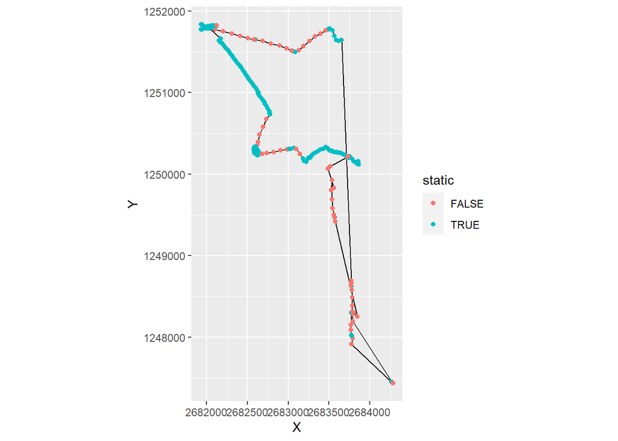

```r
posmo_filter |>
  mutate(static = stepMean < mean(posmo_filter$stepMean, na.rm = TRUE)) |>
  ggplot(aes(X, Y)) +
  geom_path() +
  geom_point(aes(color = static)) + # color of points show if the points are statics or not
  coord_fixed()
```

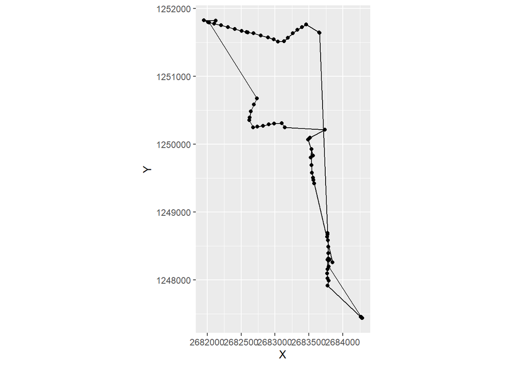

```r
# filter stops data
posmo_filter <- posmo_filter |>
  mutate(static = stepMean < mean(stepMean, na.rm = TRUE))

posmo_filter <- posmo_filter |>
    filter(!static)

#plot
posmo_filter |>
    ggplot(aes(X, Y)) +
    geom_path() +
    geom_point() +
    coord_fixed() +
    theme(legend.position = "bottom")
```

I am not satisfied by this result as a lot of trajectories have also been removed, but after a few trials, it seems lower threshold do not permit to remove entirely the static data.

## Task 4: Segment-based analysis

Assign unic ids:

```r
rle_id <- function(vec) {
    x <- rle(vec)$lengths
    as.factor(rep(seq_along(x), times = x))
}
```

```r
posmo_filter <- posmo_filter |>
    mutate(segment_id = rle_id(static))

head(posmo_filter)
```

```
## Simple feature collection with 6 features and 15 fields
## Geometry type: POINT
## Dimension:     XY
## Bounding box:  xmin: 2682030 ymin: 1250351 xmax: 2682733 ymax: 1251792
## Projected CRS: CH1903+ / LV95
## # A tibble: 6 × 16
##   datetime                   X        Y          geometry timelag
##   <dttm>                 <dbl>    <dbl>       <POINT [m]>   <dbl>
## 1 2023-05-04 05:35:56 2682030. 1251792. (2682030 1251792)       0
## 2 2023-05-04 05:45:42 2682733. 1250675. (2682733 1250675)       9
## 3 2023-05-04 05:45:51 2682691. 1250581. (2682691 1250581)       9
## 4 2023-05-04 05:46:00 2682646. 1250482. (2682646 1250482)       9
## 5 2023-05-04 05:46:09 2682627. 1250394. (2682627 1250394)       9
## 6 2023-05-04 05:46:18 2682618. 1250351. (2682618 1250351)       9
## # ℹ 11 more variables: steplength_m <dbl>, speed_ms <dbl>, n_plus1 <dbl>,
## #   n_plus2 <dbl>, n_plus3 <dbl>, n_minus1 <dbl>, n_minus2 <dbl>,
## #   n_minus3 <dbl>, stepMean <dbl>, static <lgl>, segment_id <fct>
```

## Task 5: Similarity measures

## Task 6: Calculate similarity